# Homework 2: Surafel Geleta

# Problem 1: Beauty, or not, in the classroom

## Part A

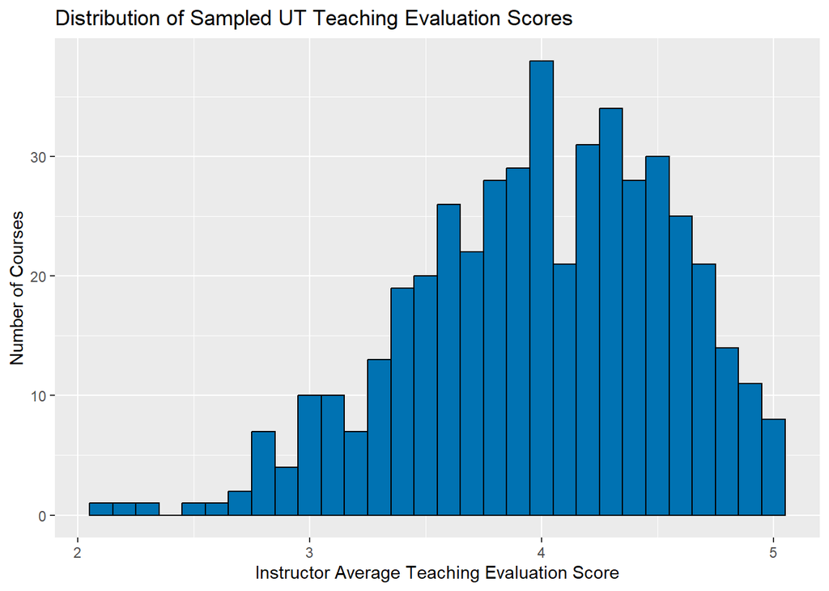

Instructors at UT Austin in the sample have a median average teaching evaluations score of 4, indicating that most of the sampled instructors are rated generally positively. The distribution of scores is left-skewed, and the IQR of average scores is 0.8, showing that 50% of instructors fall within 0.8 points of the median score.

## Part B

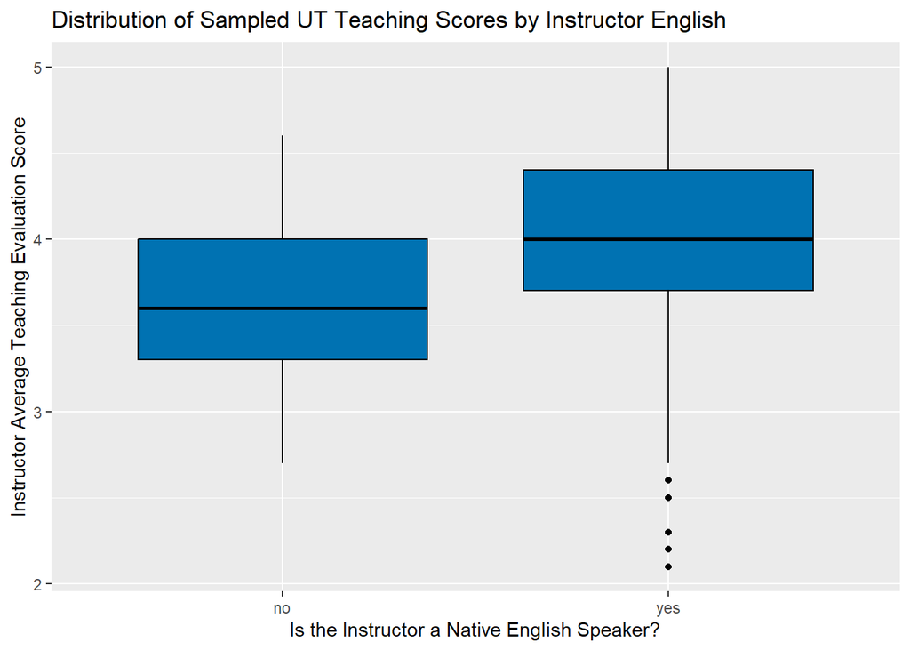

Sampled UT instructors who are native English speakers have a median average evaluation score 0.4 points higher than non-native English speaking instructors.

## Part C

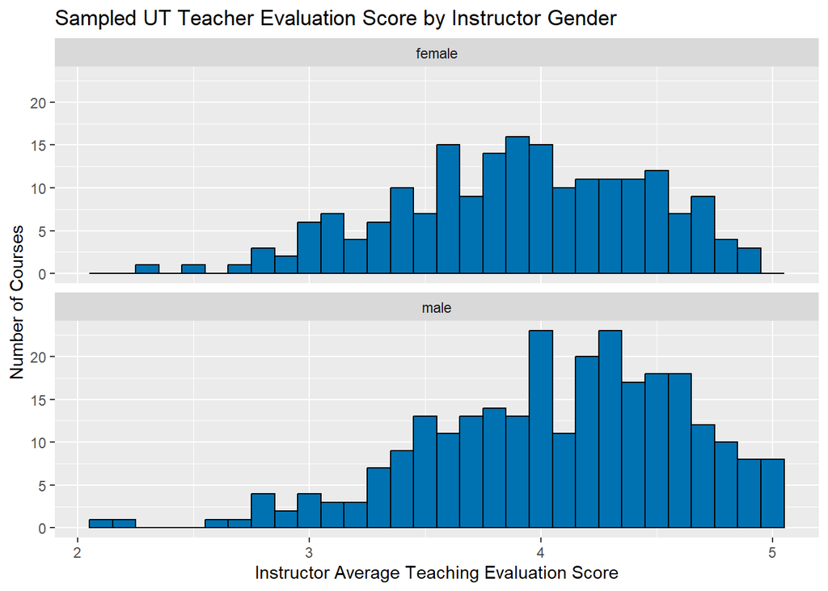

Sampled male instructors had a median average evaluation score 0.25 points higher than sampled female instructors. The distributions for both genders are left-skewed, and male instructors have a slightly wider range of evaluation scores than female instructors, with an IQR -0.1 points higher.

## Part D

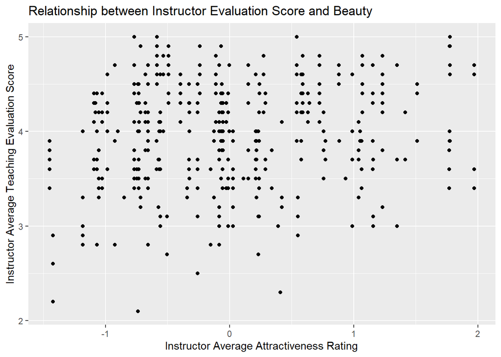

```
## [1] 0.03573578
```

# Problem 2: Bike Sharing

## Plot A

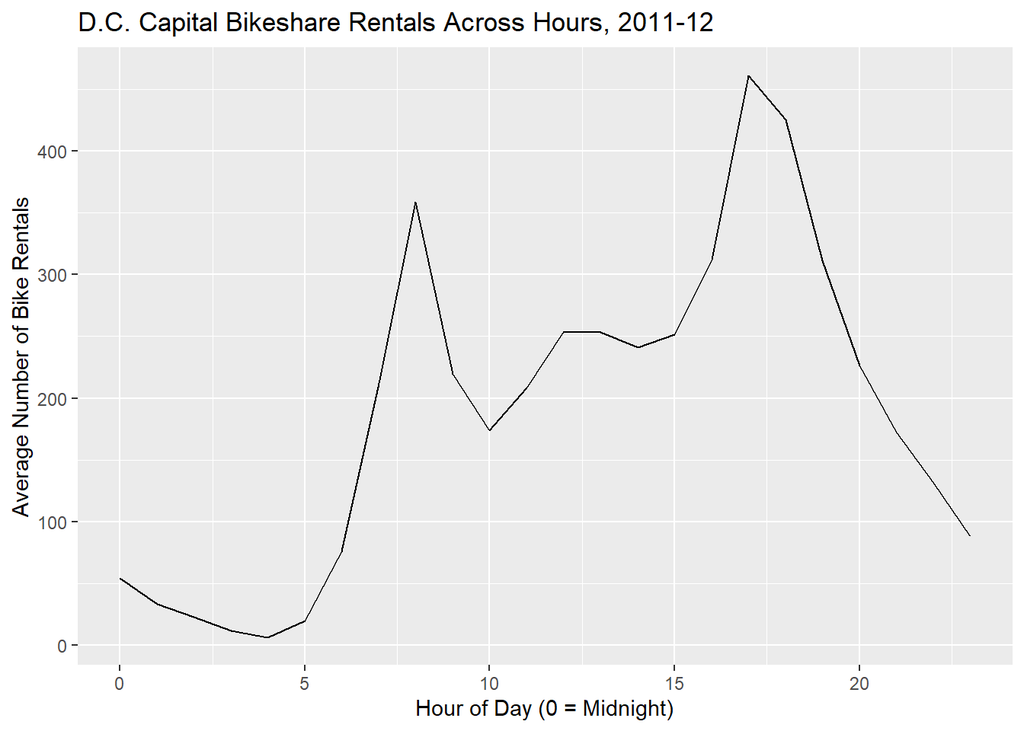

| hr | total |
| --- | --- |
| 0 | 39130 |
| 1 | 24164 |
| 2 | 16352 |
| 3 | 8174 |
| 4 | 4428 |
| 5 | 14261 |
| 6 | 55132 |
| 7 | 154171 |
| 8 | 261001 |
| 9 | 159438 |

[output cut: 14 more lines]

Starting at midnight, Bikeshare rentals remain low until 7AM, where total rentals peaked from 55,132 to 154,171. Rental totals increase to a morning peak at 8AM, with 261,001 total rentals at that hour. Rentals begin to decline sharply until 10AM, where there is a small increase in totals until noon. Beginning at 3PM, rental totals grow until an all-day peak at 5PM with 336,860 total rentals. From there, rental totals continue to fall. These patterns in rental totals appear to follow commute times; the spikes in bike rentals around 7AM and 8AM may indicate people leaving to work, while the spike through 3-5PM may indicate people leaving work.

## Plot B

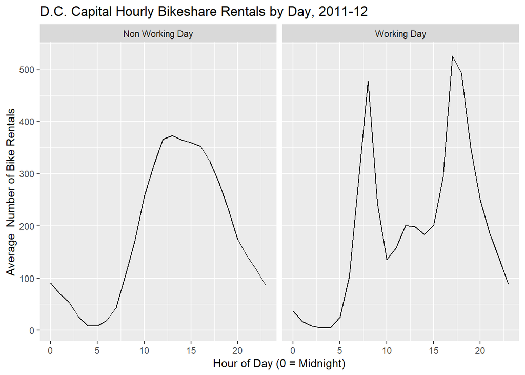

## Plot C

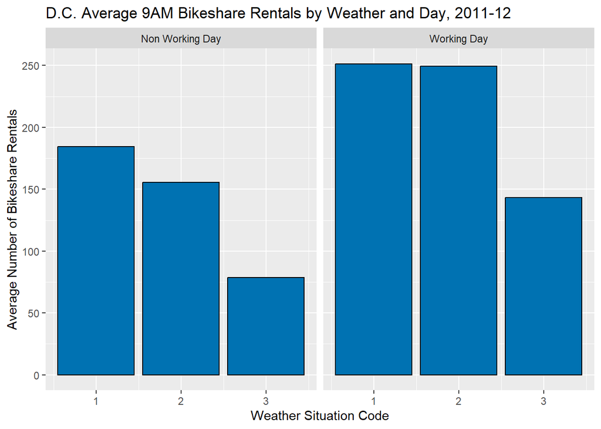

| weathersit | hr | workingday | average |
| --- | --- | --- | --- |
| 1 | 9 | Non Working Day | 184.51875 |
| 1 | 9 | Working Day | 251.29740 |
| 2 | 9 | Non Working Day | 155.55932 |
| 2 | 9 | Working Day | 249.58378 |
| 3 | 9 | Non Working Day | 78.66667 |
| 3 | 9 | Working Day | 143.35714 |

This graphic displays the average Bikeshare rentals during 9AM across different weather situations. Moreover, as with the previous graphic, there are two plots by the day status; working day and non-working day. The weather situation codes are assigned as follows: “1” indicates anywhere from clear skies to a partly cloudy day, “2” indicates cloudy days with mist, and “3” indicates precipitous days with thunderstorms and light rain, light snow, or with clouds and light rain. On working days during 9AM, average bike rentals are nearly equal between weather situations 1 and 2 (at an average of ~250 rentals), while weather situation 3 saw far less rentals made, with an average of about 143 rentals during 9AM. In addition to having lower average bike rentals across the bar, bike rentals appear to be more sensitive to weather situations on non-working days than working days during 9AM. For instance, average bike rentals fall by about 30 between weather situations 1 and 2 on non-working days, a large difference when compared to the working day difference. Moreover, on non-working days at 9AM there is a 49.43% reduction in bike rentals between weather situations 2 and 3; working days see a smaller rental reduction of 42.56% between weather situations 2 and 3 during 9AM. Overall, these results suggest that during 9AM, Bikeshare rental patterns in D.C. between 2011-12 are less responsive to negative weather changes on working days than on non-working days, perhaps due to the necessity behind arriving to work on time compared to the reduced importance of other activites on non-working days.

# Problem 3: Capital Metro UT Ridership

## Plot 1

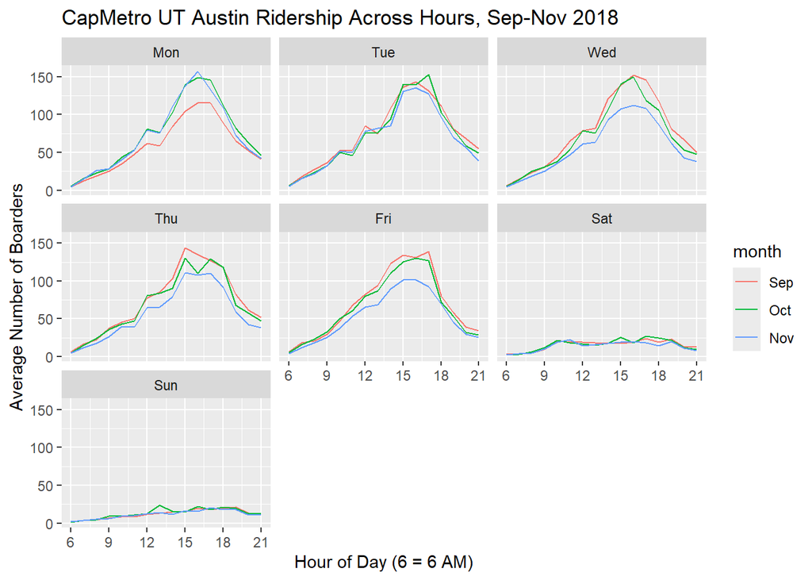

| month | hour_of_day | day_of_week | average_boarding |
| --- | --- | --- | --- |
| Sep | 6 | Sun | 1.9000 |
| Sep | 7 | Sun | 3.5500 |
| Sep | 8 | Sun | 4.1500 |
| Sep | 9 | Sun | 6.4500 |
| Sep | 10 | Sun | 8.4500 |
| Sep | 11 | Sun | 8.7000 |
| Sep | 12 | Sun | 11.9000 |
| Sep | 13 | Sun | 12.9000 |
| Sep | 14 | Sun | 14.6500 |
| Sep | 15 | Sun | 15.3500 |

[output cut: 38 more lines]

This graphic displays CapMetro’s bus ridership trends across stops around UT Austin between September and November of 2018. The y-axis shows the average, or mean, number of boarders for a given hour (Hours start at 6AM, and end at 9PM), and the x-axis shows bus operating hours within each day. The graphic is faceted, displaying 7 plots corresponding to data from each day of the week, with each plot having three color-coded lines corresponding to a month. Saturday and Sunday ridership is much lower than on weekdays; moreover, weekend ridership does not seem to follow the same patterns as weekday ridership. For instance, on Saturday average ridership peaks at 5PM in October, with an average of 26 riders within that hour; that same hour and month on Friday sees an average of around 127 riders within the hour. Weekday ridership generally follows a similar pattern, with boarding starting low at 6AM, followed by an increase in boardings until reaching peak ridership, typically between 3-5PM. From there, boardings drop steeply into the night. Peak hours vary slightly depending on the day, as well as the month; on Mondays, September boardings peak at 5PM, and October and November at 4PM. Tuesday September boardings peak at 4PM, October at 5PM, and November at 4PM. September and November Thursdays experience peak boarding during 3PM. Saturday and Sunday stray a little from this trend; in particular, peak boardings during November Saturdays occurred at 11AM, while peaks on September and October Sundays occurring at 7PM and 1PM respectively. September boardings are noticebly than October and November boardings on Mondays; this may be explained by Labor Day, which falls every 1st Monday of September, contributing to off-days from school and work. Similarly, November boardings during Wendesday-Friday are generally lower than the other months; this is likely due to Thanksgiving, which falls on the fourth Thursday of November. Wednesday may experience lower ridership due to people staying home or travelling to prepare for Thanksgiving day on Thursday, and people may rest and recover on Friday.

## Plot 2

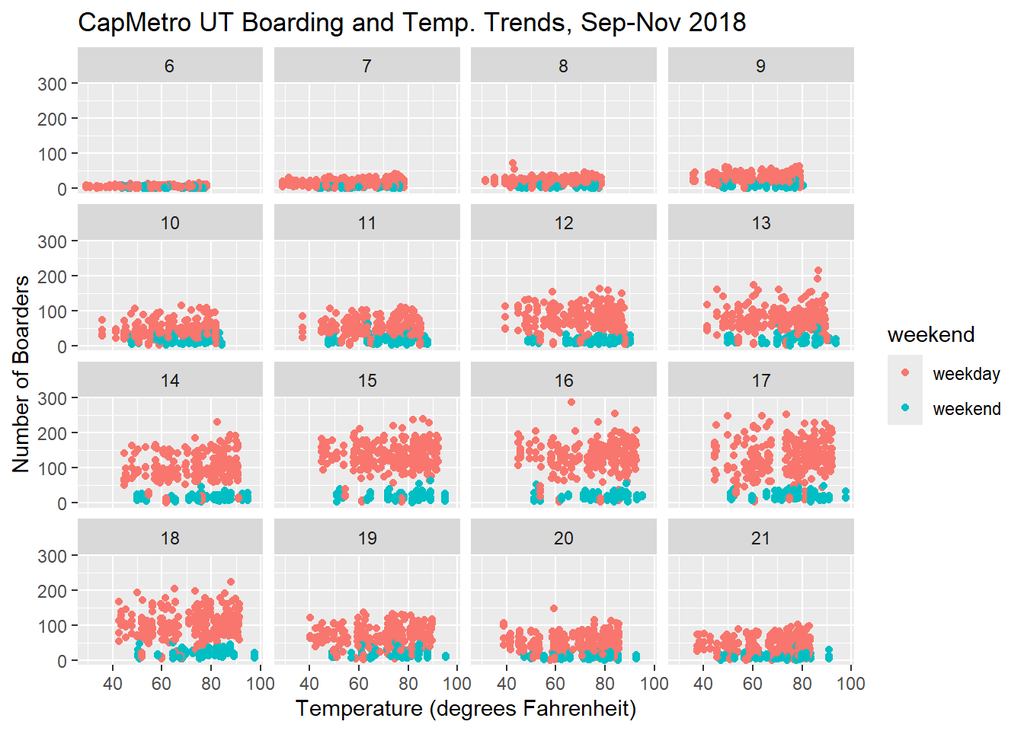

```
## [1] "Correlation coefficient for hour 6 is 0.068324126368709"
## [1] "Correlation coefficient for hour 7 is 0.0151944954557296"
## [1] "Correlation coefficient for hour 8 is 0.0169668001926163"
## [1] "Correlation coefficient for hour 9 is 0.00401516315388477"
## [1] "Correlation coefficient for hour 10 is 0.0382847367074782"
## [1] "Correlation coefficient for hour 11 is 0.01479639822279"
## [1] "Correlation coefficient for hour 12 is -0.0682206859927336"
## [1] "Correlation coefficient for hour 13 is -0.0252704939691378"
## [1] "Correlation coefficient for hour 14 is 0.0176581197900705"
## [1] "Correlation coefficient for hour 15 is -0.0627203567907833"
## [1] "Correlation coefficient for hour 16 is -0.0207611313175556"
## [1] "Correlation coefficient for hour 17 is 0.010031141326945"
## [1] "Correlation coefficient for hour 18 is 0.0141884826467895"
## [1] "Correlation coefficient for hour 19 is 0.0430411492957514"
## [1] "Correlation coefficient for hour 20 is 0.0301031824332216"
## [1] "Correlation coefficient for hour 21 is 0.0163650567153157"
```

This graphic displays the relationship between temperature and total boarding in CapMetro’s UT Austin routes, faceted to include a plot of the relationship for each operating hour of the day. Temperatures increase as the day approaches mid-afternoon (3-5PM), seen with how the points generally shift right between 6AM and 5PM; temperatures begin to decline after 5PM. In addition, the plots indicate that weekend boarding counts are significantly lower than weekday boardings across all available hours. When holding the hour of the day and day type constant, there is little evidence of an association between temperature and the number of boarders. The Pearson correlation coefficient values across all hours are incredibly low, varying between -0.0682 to 0.0683, which indicate no linear relationship.

# Problem 4: Wrangling the Billboard Top 100

## Part A

Top 10 Most Popular Songs By Count of Weeks Spent on Billboard Top 100

| Performer | Song | Count |
| --- | --- | --- |
| Imagine Dragons | Radioactive | 87 |
| AWOLNATION | Sail | 79 |
| Jason Mraz | I’m Yours | 76 |
| The Weeknd | Blinding Lights | 76 |
| LeAnn Rimes | How Do I Live | 69 |
| LMFAO Featuring Lauren Bennett & GoonRock | Party Rock Anthem | 68 |
| OneRepublic | Counting Stars | 68 |
| Adele | Rolling In The Deep | 65 |
| Jewel | Foolish Games/You Were Meant For Me | 65 |
| Carrie Underwood | Before He Cheats | 64 |

## Part B

[figure not shown]

## Part C

[figure not shown]